# Connecting to Google BigQuery with DBplyr

John R Little

2021-02-23

## Google Cloud Account & Big Query

1. Get a Google Cloud account
   - [BigQuery sandbox](https://cloud.google.com/bigquery/docs/sandbox)
   - [Google Cloud Free Program](https://cloud.google.com/free/docs/gcp-free-tier)
   - [BigQuery public datasets](https://cloud.google.com/bigquery/public-data)
   - [BigQuery](https://cloud.google.com/bigquery)
   - [GCP-BigQuery Console](https://console.cloud.google.com/bigquery)

No Credit Card? [Use the BigQuery sandbox](https://cloud.google.com/blog/products/data-analytics/query-without-a-credit-card-introducing-bigquery-sandbox)

## Library packages

```r
library(tidyverse)
library(DBI)
library(bigrquery)
```

BigQuery refers to tables in the format `database.dataset.table`. For example, you can run this query in the BigQuery Console

```
select * from bigquery-public-data.stackoverflow.users limit 10;
```

## Establish a database connection

First create a new GCP project in the GCP. The `dbConnect()` argument, `billing`, should have the value of a GCP **project ID**

GPC > Home > Dashboard GPC > BigQuery

```r
# library(DBI)

con <- dbConnect(
  bigquery(),
  project = "bigquery-public-data",
  dataset = "covid19_jhu_csse",
  billing = "workshop-rfun-2021-spring"
)
con
```

```
<BigQueryConnection>
  Dataset: bigquery-public-data.covid19_jhu_csse
  Billing: workshop-rfun-2021-spring
```

Now, from **within the R console**, authenticate with GCP

```
bigrquery::bq_auth()
```

## Create a pointer to a Google BQ database table

Our goal is to investigate and search the JHU COVID19 *summary* **table**. i.e. bigquery-public-data.covid19_jhu_csse.summary

```r
my_db_pointer <- tbl(con, "summary")
```

Now I can use [dplyr verbs](https://dplyr.tidyverse.org/) to explore the db table.

```r
# roughly:  SELECT * FROM bigquery-public-data.covid19_jhu_csse.summary limit 10;
glimpse(my_db_pointer)
```

```
Rows: ??
Columns: 13
Database: BigQueryConnection
$ province_state <chr> "Utah", "Utah", "Vermont", "Massachusetts", "Nevada", "Arizona", "District of Columbia", "Massa...
$ country_region <chr> "US", "US", "US", "US", "US", "US", "US", "US", "US", "US", "US", "US", "US", "US", "US", "US",...
$ date           <date> 2020-08-26, 2020-08-26, 2020-08-26, 2020-04-20, 2020-04-20, 2020-04-20, 2020-04-20, 2020-04-20...
$ latitude       <dbl> 40.66617, 40.11667, 44.46323, 41.79228, 36.21459, 35.83883, 38.90418, 42.66876, 41.26810, 42.13...
$ longitude      <dbl> -111.92160, -111.66577, -73.08359, -71.10872, -115.01302, -111.77072, -77.01656, -70.94687, -73...
$ location_geom  <wk_wkt> POINT (-111.922 40.6662), POINT (-111.666 40.1167), POINT (-73.0836 44.4632), POINT (-71.108...
$ confirmed      <int> 23186, 10435, 780, 1731, 2998, 337, 2927, 5153, 8320, 2337, 3823, 639, 2636, 484, 8737, 1229, 5...
$ deaths         <int> 227, 46, 39, 87, 137, 31, 105, 209, 512, 211, 369, 58, 75, 45, 372, 33, 301, 244, 58, 131, 236,...
$ recovered      <int> 0, 0, 0, 0, 0, 0, 0, 0, 0, 0, 0, 0, 0, 0, 0, 0, 0, 0, 0, 0, 0, 0, 0, 0, 0, 0, 0, 0, 0, 0, 0, 0,...
$ active         <int> 22959, 10389, 741, 1644, 2861, 306, 2822, 4944, 7808, 2126, 3454, 581, 2561, 439, 8365, 1196, 4...
$ fips           <chr> "49035", "49049", "50007", "25005", "32003", "04005", "11001", "25009", "09001", "25013", "0900...
$ admin2         <chr> "Salt Lake", "Utah", "Chittenden", "Bristol", "Clark", "Coconino", "District of Columbia", "Ess...
$ combined_key   <chr> "Salt Lake, Utah, US", "Utah, Utah, US", "Chittenden, Vermont, US", "Bristol, Massachusetts, US...
```

```r
# roughly:  SELECT count( * ) FROM summary
count(my_db_pointer)
```

```
Complete
Billed: 0 B
Downloading 1 rows in 1 pages.
```

| n |
| --- |
| 1281361 |

## SQL

Using `DBI`, you can compose SQL directly. See also, [Writing SQL with dbplyr](https://dbplyr.tidyverse.org/articles/sql.html)

```
{r}
DBI::dbGetQuery(con,
"SELECT *
FROM `bigquery-public-data.covid19_jhu_csse.summary`
LIMIT 10;")
```

### Examples of a more complex SQL query

```
{r}
jhu_covid19_nc_counties_10 <- dbGetQuery(con,
           "SELECT
              admin2, province_state, confirmed
            FROM
              `bigquery-public-data.covid19_jhu_csse.summary`
            WHERE
              country_region = 'US'
              AND date = '2020-06-30'
              AND province_state = 'North Carolina'
            LIMIT 10;"
)
jhu_covid19_nc_counties_10
```

```
{r}
jhu_covid19_nc_counties <- dbGetQuery(con,
           "SELECT
              admin2, province_state, confirmed
            FROM
              `bigquery-public-data.covid19_jhu_csse.summary`
            WHERE
              country_region = 'US'
              AND date = '2020-06-30'
              AND province_state = 'North Carolina'"
)
jhu_covid19_nc_counties
```

Similar to `glimpse()` but more SQLish

```r
bigrquery::bq_table_fields("bigquery-public-data.austin_bikeshare.bikeshare_trips")
```

## dpplyr/dbplyr approach

If you don’t know SQL, or are more comfortable with `dplyr`, you can compose your queries with `dplyr` verbs. `dbplyr` is the backend to `dplyr` and will broker the process. In practice you do not need to call `dbplyr` and the easiest thing to do is load `library(tidyverse)` at the top of your script.

First *connect to a table* using the `tbl()` function. This assumes you have already used `DBI::dbConnect()` to broker the database connection – as we did above.

```r
covid_data_DBplyr_style <- tbl(con, "summary")
```

> Note: `collect()` will run a query that has been assigned to an object.

`collect()` will activate your SQL query. Normally, I will try to use use the `collect()` sparingly to economize my connections to the remote database, and limit the data I am requesting from the DB server. My goal is push my data processing up to the RDBMS server as much as possible.

```
covid_data_DBplyr_style %>%
  collect()   # this will gather all the data from the summary table
```

Above will pull the entire data table down into local RAM. A better approach is to leverage dplyr. Let dplyr/dbplyr translate queries into SQL and send those to the SQL engine. This allows use to use the RDMBS for summarizing data while using local RAM and CPU for retrieving only the data you want to manipulate.

```r
jhu_covid19_DBP_nc_counties <- covid_data_DBplyr_style %>%
  filter(province_state == "North Carolina", date == '2020-06-30')  %>%
  select(province_state, country_region, date, latitude,
         longitude, confirmed, deaths, #location_geom,
         recovered, active, fips, admin2, combined_key)

jhu_covid19_DBP_nc_counties
```

```
Complete
Billed: 0 B
Downloading 101 rows in 1 pages.
```

| province_state | country_region | date | latitude | longitude | confirmed | deaths | recovered | active | fips | admin2 | combined_key |
| --- | --- | --- | --- | --- | --- | --- | --- | --- | --- | --- | --- |
| North Carolina | US | 2020-06-30 | 36.04347 | -79.39976 | 1146 | 37 | 0 | 1109 | 37001 | Alamance | Alamance, North Carolina, US |
| North Carolina | US | 2020-06-30 | 35.61113 | -82.53305 | 591 | 40 | 0 | 551 | 37021 | Buncombe | Buncombe, North Carolina, US |
| North Carolina | US | 2020-06-30 | 35.38778 | -80.55267 | 1164 | 32 | 0 | 1132 | 37025 | Cabarrus | Cabarrus, North Carolina, US |
| North Carolina | US | 2020-06-30 | 35.70394 | -79.25541 | 950 | 43 | 0 | 907 | 37037 | Chatham | Chatham, North Carolina, US |
| North Carolina | US | 2020-06-30 | 34.26744 | -78.65801 | 521 | 38 | 0 | 483 | 37047 | Columbus | Columbus, North Carolina, US |
| North Carolina | US | 2020-06-30 | 35.04762 | -78.82623 | 1180 | 41 | 0 | 1139 | 37051 | Cumberland | Cumberland, North Carolina, US |
| North Carolina | US | 2020-06-30 | 36.03638 | -78.87608 | 3679 | 63 | 0 | 3616 | 37063 | Durham | Durham, North Carolina, US |
| North Carolina | US | 2020-06-30 | 36.12860 | -80.25459 | 2996 | 34 | 0 | 2962 | 37067 | Forsyth | Forsyth, North Carolina, US |
| North Carolina | US | 2020-06-30 | 36.07959 | -79.78825 | 2812 | 114 | 0 | 2698 | 37081 | Guilford | Guilford, North Carolina, US |
| North Carolina | US | 2020-06-30 | 35.33789 | -82.47668 | 610 | 50 | 0 | 560 | 37089 | Henderson | Henderson, North Carolina, US |

[output cut: 91 more lines]

### show_query()

If you want to see the SQL

```r
jhu_covid19_DBP_nc_counties %>%
  show_query()
```

```
<SQL>
SELECT `province_state`, `country_region`, `date`, `latitude`, `longitude`, `confirmed`, `deaths`, `recovered`, `active`, `fips`, `admin2`, `combined_key`
FROM `summary`
WHERE ((`province_state` = 'North Carolina') AND (`date` = '2020-06-30'))
```

See Also [Writing SQL with dbplyr](https://dbplyr.tidyverse.org/articles/sql.html)  
See Also dbplyr > Articles > Verb translation  
See Also dbplyr > Articles > Function translation

### Variations

The following are some initial variations using dplyr verbs to create SQL queries, and connect with the RDMBS in a client/server fashion.

```r
glimpse(my_db_pointer)
```

```
Rows: ??
Columns: 13
Database: BigQueryConnection
$ province_state <chr> "Arizona", "Arizona", "Arizona", "Arizona", "Arizona", "Arizona", "Arizona", "Arizona", "Arizon...
$ country_region <chr> "US", "US", "US", "US", "US", "US", "US", "US", "US", "US", "US", "US", "US", "US", "US", "US",...
$ date           <date> 2020-09-17, 2020-09-17, 2020-09-17, 2020-09-17, 2020-09-17, 2020-09-17, 2020-09-17, 2020-09-17...
$ latitude       <dbl> 35.39465, 31.87935, 35.83883, 33.80190, 33.34836, 35.70472, 35.39977, 32.09713, 32.90526, 31.52...
$ longitude      <dbl> -109.48924, -109.75161, -111.77072, -110.81328, -112.49182, -113.75779, -110.32190, -111.78900,...
$ location_geom  <wk_wkt> POINT (-109.489 35.3947), POINT (-109.752 31.8793), POINT (-111.771 35.8388), POINT (-110.81...
$ confirmed      <int> 3417, 1872, 3644, 1208, 139051, 3817, 5733, 23563, 10263, 2801, 2442, 12472, 19678, 14205, 1815...
$ deaths         <int> 159, 69, 133, 51, 3210, 221, 231, 612, 200, 61, 80, 341, 1419, 1434, 140, 193, 1111, 111, 65, 1...
$ recovered      <int> 0, 0, 0, 0, 0, 0, 0, 0, 0, 0, 0, 0, 0, 0, 0, 0, 0, 0, 0, 0, 0, 0, 0, 0, 0, 0, 0, 0, 0, 0, 0, 0,...
$ active         <int> 3258, 1803, 3511, 1157, 135841, 3596, 5502, 22951, 10063, 2740, 2362, 12131, 18259, 12771, 1675...
$ fips           <chr> "04001", "04003", "04005", "04007", "04013", "04015", "04017", "04019", "04021", "04023", "0402...
$ admin2         <chr> "Apache", "Cochise", "Coconino", "Gila", "Maricopa", "Mohave", "Navajo", "Pima", "Pinal", "Sant...
$ combined_key   <chr> "Apache, Arizona, US", "Cochise, Arizona, US", "Coconino, Arizona, US", "Gila, Arizona, US", "M...
```

```r
my_search <- my_db_pointer %>%
  filter(province_state == "North Carolina", date == '2020-06-30')  %>%
  select(province_state, country_region, date, latitude,
         longitude, confirmed, deaths, #location_geom,
         recovered, active, fips, admin2, combined_key)

my_search
```

```
Complete
Billed: 0 B
Downloading 101 rows in 1 pages.
```

| province_state | country_region | date | latitude | longitude | confirmed | deaths | recovered | active | fips | admin2 | combined_key |
| --- | --- | --- | --- | --- | --- | --- | --- | --- | --- | --- | --- |
| North Carolina | US | 2020-06-30 | 36.04347 | -79.39976 | 1146 | 37 | 0 | 1109 | 37001 | Alamance | Alamance, North Carolina, US |
| North Carolina | US | 2020-06-30 | 35.61113 | -82.53305 | 591 | 40 | 0 | 551 | 37021 | Buncombe | Buncombe, North Carolina, US |
| North Carolina | US | 2020-06-30 | 35.38778 | -80.55267 | 1164 | 32 | 0 | 1132 | 37025 | Cabarrus | Cabarrus, North Carolina, US |
| North Carolina | US | 2020-06-30 | 35.70394 | -79.25541 | 950 | 43 | 0 | 907 | 37037 | Chatham | Chatham, North Carolina, US |
| North Carolina | US | 2020-06-30 | 34.26744 | -78.65801 | 521 | 38 | 0 | 483 | 37047 | Columbus | Columbus, North Carolina, US |
| North Carolina | US | 2020-06-30 | 35.04762 | -78.82623 | 1180 | 41 | 0 | 1139 | 37051 | Cumberland | Cumberland, North Carolina, US |
| North Carolina | US | 2020-06-30 | 36.03638 | -78.87608 | 3679 | 63 | 0 | 3616 | 37063 | Durham | Durham, North Carolina, US |
| North Carolina | US | 2020-06-30 | 36.12860 | -80.25459 | 2996 | 34 | 0 | 2962 | 37067 | Forsyth | Forsyth, North Carolina, US |
| North Carolina | US | 2020-06-30 | 36.07959 | -79.78825 | 2812 | 114 | 0 | 2698 | 37081 | Guilford | Guilford, North Carolina, US |
| North Carolina | US | 2020-06-30 | 35.33789 | -82.47668 | 610 | 50 | 0 | 560 | 37089 | Henderson | Henderson, North Carolina, US |

[output cut: 91 more lines]

```r
my_search %>%
  collect()
```

```
Complete
Billed: 0 B
Downloading 101 rows in 1 pages.
```

| province_state | country_region | date | latitude | longitude | confirmed | deaths | recovered | active | fips | admin2 | combined_key |
| --- | --- | --- | --- | --- | --- | --- | --- | --- | --- | --- | --- |
| North Carolina | US | 2020-06-30 | 36.04347 | -79.39976 | 1146 | 37 | 0 | 1109 | 37001 | Alamance | Alamance, North Carolina, US |
| North Carolina | US | 2020-06-30 | 35.61113 | -82.53305 | 591 | 40 | 0 | 551 | 37021 | Buncombe | Buncombe, North Carolina, US |
| North Carolina | US | 2020-06-30 | 35.38778 | -80.55267 | 1164 | 32 | 0 | 1132 | 37025 | Cabarrus | Cabarrus, North Carolina, US |
| North Carolina | US | 2020-06-30 | 35.70394 | -79.25541 | 950 | 43 | 0 | 907 | 37037 | Chatham | Chatham, North Carolina, US |
| North Carolina | US | 2020-06-30 | 34.26744 | -78.65801 | 521 | 38 | 0 | 483 | 37047 | Columbus | Columbus, North Carolina, US |
| North Carolina | US | 2020-06-30 | 35.04762 | -78.82623 | 1180 | 41 | 0 | 1139 | 37051 | Cumberland | Cumberland, North Carolina, US |
| North Carolina | US | 2020-06-30 | 36.03638 | -78.87608 | 3679 | 63 | 0 | 3616 | 37063 | Durham | Durham, North Carolina, US |
| North Carolina | US | 2020-06-30 | 36.12860 | -80.25459 | 2996 | 34 | 0 | 2962 | 37067 | Forsyth | Forsyth, North Carolina, US |
| North Carolina | US | 2020-06-30 | 36.07959 | -79.78825 | 2812 | 114 | 0 | 2698 | 37081 | Guilford | Guilford, North Carolina, US |
| North Carolina | US | 2020-06-30 | 35.33789 | -82.47668 | 610 | 50 | 0 | 560 | 37089 | Henderson | Henderson, North Carolina, US |

[output cut: 91 more lines]

### Collecting all the data into a local tibble

```r
jhu_covid19_durham_sinceApril <- covid_data_DBplyr_style %>%
  filter(province_state == "North Carolina",
         admin2 == "Durham",
         date >= '2020-04-01')  %>%
  select(date, confirmed, deaths, recovered, active,
         fips, admin2, combined_key)

my_local_tbl <- jhu_covid19_durham_sinceApril %>%
  collect()
```

```
Complete
Billed: 0 B
Downloading 328 rows in 1 pages.
```

```r
my_local_tbl
```

| date | confirmed | deaths | recovered | active | fips | admin2 | combined_key |
| --- | --- | --- | --- | --- | --- | --- | --- |
| 2020-09-17 | 7418 | 88 | 0 | 7330 | 37063 | Durham | Durham, North Carolina, US |
| 2020-06-27 | 3532 | 63 | 0 | 3469 | 37063 | Durham | Durham, North Carolina, US |
| 2020-10-26 | 8890 | 100 | 0 | 8790 | 37063 | Durham | Durham, North Carolina, US |
| 2020-08-18 | 6447 | 81 | 0 | 6366 | 37063 | Durham | Durham, North Carolina, US |
| 2020-08-12 | 6231 | 80 | 0 | 6151 | 37063 | Durham | Durham, North Carolina, US |
| 2020-09-01 | 6942 | 84 | 0 | 6858 | 37063 | Durham | Durham, North Carolina, US |
| 2020-12-17 | 13162 | 129 | 0 | 13033 | 37063 | Durham | Durham, North Carolina, US |
| 2020-05-17 | 1000 | 39 | 0 | 961 | 37063 | Durham | Durham, North Carolina, US |
| 2020-06-11 | 2370 | 53 | 0 | 2317 | 37063 | Durham | Durham, North Carolina, US |
| 2020-08-30 | 6878 | 84 | 0 | 6794 | 37063 | Durham | Durham, North Carolina, US |

[output cut: 318 more lines]

```r
jhu_covid19_durham_sinceApril %>%
  arrange(date)
```

```
Complete
Billed: 0 B
Downloading 328 rows in 1 pages.
```

| date | confirmed | deaths | recovered | active | fips | admin2 | combined_key |
| --- | --- | --- | --- | --- | --- | --- | --- |
| 2020-04-01 | 126 | 0 | 0 | 0 | 37063 | Durham | Durham, North Carolina, US |
| 2020-04-02 | 147 | 0 | 0 | 0 | 37063 | Durham | Durham, North Carolina, US |
| 2020-04-03 | 159 | 0 | 0 | 0 | 37063 | Durham | Durham, North Carolina, US |
| 2020-04-04 | 182 | 1 | 0 | 0 | 37063 | Durham | Durham, North Carolina, US |
| 2020-04-05 | 186 | 1 | 0 | 0 | 37063 | Durham | Durham, North Carolina, US |
| 2020-04-06 | 191 | 1 | 0 | 0 | 37063 | Durham | Durham, North Carolina, US |
| 2020-04-07 | 219 | 1 | 0 | 0 | 37063 | Durham | Durham, North Carolina, US |
| 2020-04-08 | 236 | 1 | 0 | 0 | 37063 | Durham | Durham, North Carolina, US |
| 2020-04-09 | 243 | 1 | 0 | 0 | 37063 | Durham | Durham, North Carolina, US |
| 2020-04-10 | 259 | 1 | 0 | 0 | 37063 | Durham | Durham, North Carolina, US |

[output cut: 318 more lines]

```r
my_local_tbl %>%
  arrange(date)
```

| date | confirmed | deaths | recovered | active | fips | admin2 | combined_key |
| --- | --- | --- | --- | --- | --- | --- | --- |
| 2020-04-01 | 126 | 0 | 0 | 0 | 37063 | Durham | Durham, North Carolina, US |
| 2020-04-02 | 147 | 0 | 0 | 0 | 37063 | Durham | Durham, North Carolina, US |
| 2020-04-03 | 159 | 0 | 0 | 0 | 37063 | Durham | Durham, North Carolina, US |
| 2020-04-04 | 182 | 1 | 0 | 0 | 37063 | Durham | Durham, North Carolina, US |
| 2020-04-05 | 186 | 1 | 0 | 0 | 37063 | Durham | Durham, North Carolina, US |
| 2020-04-06 | 191 | 1 | 0 | 0 | 37063 | Durham | Durham, North Carolina, US |
| 2020-04-07 | 219 | 1 | 0 | 0 | 37063 | Durham | Durham, North Carolina, US |
| 2020-04-08 | 236 | 1 | 0 | 0 | 37063 | Durham | Durham, North Carolina, US |
| 2020-04-09 | 243 | 1 | 0 | 0 | 37063 | Durham | Durham, North Carolina, US |
| 2020-04-10 | 259 | 1 | 0 | 0 | 37063 | Durham | Durham, North Carolina, US |

[output cut: 318 more lines]

### Visualize

Creating visualizations requires 100% of the data. the [dbplot package](https://db.rstudio.com/dbplot) provides helper functions that automate the aggregation and plotting steps. `dbplot` is an alternative visualization approach to assist in the best practices of *transforming* data in the database, then *plotting* in R. Please also see this fuller [discussion on creating visualizations](https://db.rstudio.com/best-practices/visualization/) from databases using R.

[output not shown]

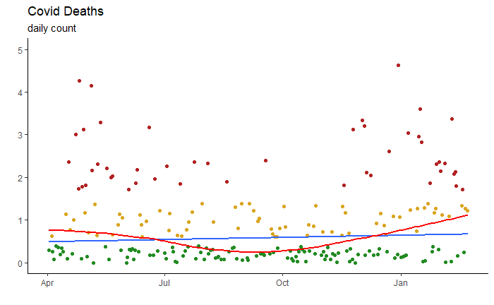

```r
jhu_covid19_durham_sinceApril %>%
  arrange(date) %>%
  mutate(daily_count = deaths - lag(deaths)) %>%
  filter(daily_count > -1) %>%
  mutate(scare = case_when(
    daily_count >= 2 ~ "high",
    daily_count == 1 ~ "medium",
    daily_count == 0 ~ "low"
  )) %>%
  ggplot(aes(date, daily_count, "low", "medium")) +
  geom_jitter(aes(color = fct_relevel(scare, "low", "medium"))) +
  geom_smooth(method = lm, se = FALSE) +
  geom_smooth(color = "red", se = FALSE) +
  scale_color_manual(values = c("forestgreen", "goldenrod", "firebrick")) +
  ylim(0, 5) +
  guides(color = FALSE) +
  labs(title = "Covid Deaths", subtitle = "daily count",
       y = "", x = "") +
  theme_classic()
```

[output not shown]

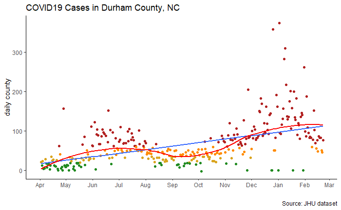

```r
jhu_covid19_durham_sinceApril %>%
  arrange(date) %>%
  mutate(daily_count = confirmed - lag(confirmed)) %>%
  mutate(scare = case_when(
    daily_count > 59 ~ "extreme",
    daily_count <= 59 & daily_count > 36  ~ "high",
    daily_count <= 36 & daily_count > 19 ~ "medium",
    daily_count <= 19 ~ "low"
  )) %>%
  ggplot(aes(date, daily_count, "low", "medium")) +
  geom_point(aes(color = fct_relevel(scare, "low", "medium", "high", "extreme"))) +
  geom_smooth(method = lm, se = FALSE) +
  geom_smooth(color = "red", se = FALSE) +
  scale_color_manual(values = c("forestgreen", "goldenrod", "darkorange", "firebrick")) +
  scale_x_date(breaks = "1 month", date_labels = "%b") +
  guides(color = FALSE) +
  labs(title = "COVID19 Cases in Durham County, NC",
       x = "", y = "daily county",
       caption = "Source: JHU dataset") +
  theme_classic()
```

```r
jhu_covid19_DBP_nc_counties %>%
  select(admin2, fips, province_state, confirmed, deaths) %>%
  rename(county = admin2, state = province_state, cases = confirmed) %>%
  arrange(-deaths)
```

```
Complete
Billed: 0 B
Downloading 101 rows in 1 pages.
```

| county | fips | state | cases | deaths |
| --- | --- | --- | --- | --- |
| Mecklenburg | 37119 | North Carolina | 11170 | 150 |
| Guilford | 37081 | North Carolina | 2812 | 114 |
| Durham | 37063 | North Carolina | 3679 | 63 |
| Henderson | 37089 | North Carolina | 610 | 50 |
| Wake | 37183 | North Carolina | 5178 | 47 |
| Chatham | 37037 | North Carolina | 950 | 43 |
| Rowan | 37159 | North Carolina | 1205 | 42 |
| Orange | 37135 | North Carolina | 669 | 41 |
| Cumberland | 37051 | North Carolina | 1180 | 41 |
| Buncombe | 37021 | North Carolina | 591 | 40 |

[output cut: 91 more lines]

## SQL – MORE

[output not shown]

```sql
SELECT `province_state`, `country_region`, `date`,
       `latitude`, `longitude`, `confirmed`, `deaths`,
       `recovered`, `active`, `fips`, `admin2`, `combined_key`
FROM `summary`
WHERE ((`province_state` = 'North Carolina') AND (`date` = '2020-06-30'))
```

Above code chunk created the tibble `special_df` as identified in output.var

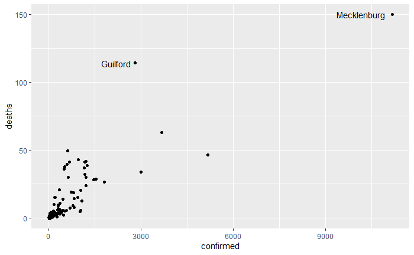

```r
special_df %>%
  ggplot(aes(confirmed, deaths)) +
  geom_jitter() +
  geom_text(data = . %>% filter(deaths > 100),
            aes(confirmed, deaths, label = admin2, hjust = 1.15))
```

## Example 2a: DBplyr and Austin Bikeshare trips

Make the connection to the `bigquery-public-data.austin_bikeshare` database.

```r
con2_bq_bikes <- dbConnect(
  bigrquery::bigquery(),
  project = "bigquery-public-data",
  dataset = "austin_bikeshare",
  billing = "workshop-rfun-2021-spring"
)
con2_bq_bikes
```

```
<BigQueryConnection>
  Dataset: bigquery-public-data.austin_bikeshare
  Billing: workshop-rfun-2021-spring
```

Set the query pointer to `bigquery-public-data.austin_bikeshare.bikeshare_trips` table.

```r
bikeshare_trips <- tbl(con2_bq_bikes, "bikeshare_trips")
```

```r
austin_bikeshare_all <- bikeshare_trips %>%
  mutate(trip_id = as.double(trip_id)) %>%
  # filter(subscriber_type == "Walk Up") %>%
  collect()
```

[output not shown]

[output cut: 97 more lines]

[output not shown]

```r
austin_bikeshare_all
```

| trip_id | subscriber_type | bikeid | start_time | start_station_id | start_station_name | end_station_id | end_station_name | duration_minutes |
| --- | --- | --- | --- | --- | --- | --- | --- | --- |
| 9900289692 | Walk Up | 248 | 2015-10-02 21:12:01 | 1006 | Zilker Park West | 1008 | Nueces @ 3rd | 39 |
| 9900285987 | 24-Hour Kiosk (Austin B-cycle) | 446 | 2014-10-26 15:12:00 | 2712 | Toomey Rd @ South Lamar | 2712 | Toomey Rd @ South Lamar | 31 |
| 9900285989 | 24-Hour Kiosk (Austin B-cycle) | 203 | 2014-10-26 15:12:00 | 2712 | Toomey Rd @ South Lamar | 2712 | Toomey Rd @ South Lamar | 31 |
| 9900285991 | 24-Hour Kiosk (Austin B-cycle) | 101 | 2014-10-26 15:12:00 | 2712 | Toomey Rd @ South Lamar | 2712 | Toomey Rd @ South Lamar | 30 |
| 9900286140 | 24-Hour Kiosk (Austin B-cycle) | 242 | 2014-10-26 18:12:00 | 2541 | State Capitol @ 14th & Colorado | 2541 | State Capitol @ 14th & Colorado | 19 |
| 9900286143 | 24-Hour Kiosk (Austin B-cycle) | 924 | 2014-10-26 18:12:00 | 2541 | State Capitol @ 14th & Colorado | 2541 | State Capitol @ 14th & Colorado | 17 |
| 9900286171 | 24-Hour Kiosk (Austin B-cycle) | 869 | 2014-10-26 18:12:00 | 2536 | Waller & 6th St. | 2536 | Waller & 6th St. | 6 |
| 9900286214 | Annual Membership (Austin B-cycle) | 24 | 2014-10-26 20:12:00 | 2712 | Toomey Rd @ South Lamar | 2712 | Toomey Rd @ South Lamar | 0 |
| 9900286540 | 24-Hour Kiosk (Austin B-cycle) | 117 | 2014-10-27 15:12:00 | 2536 | Waller & 6th St. | 2536 | Waller & 6th St. | 12 |
| 13575843 | Walk Up | 302 | 2017-01-29 16:42:52 | 3464 | Pease Park | 3464 | Pease Park | 47 |

[output cut: 990 more lines]

```r
glimpse(austin_bikeshare_all)
```

```
Rows: 1,264,113
Columns: 9
$ trip_id            <dbl> 9900289692, 9900285987, 9900285989, 9900285991, 9900286140, 9900286143, 9900286171, 9900286...
$ subscriber_type    <chr> "Walk Up", "24-Hour Kiosk (Austin B-cycle)", "24-Hour Kiosk (Austin B-cycle)", "24-Hour Kio...
$ bikeid             <chr> "248", "446", "203", "101", "242", "924", "869", "24", "117", "302", "894", "996", "894", "...
$ start_time         <dttm> 2015-10-02 21:12:01, 2014-10-26 15:12:00, 2014-10-26 15:12:00, 2014-10-26 15:12:00, 2014-1...
$ start_station_id   <int> 1006, 2712, 2712, 2712, 2541, 2541, 2536, 2712, 2536, 3464, 2541, 2541, 2541, 2712, 2536, 2...
$ start_station_name <chr> "Zilker Park West", "Toomey Rd @ South Lamar", "Toomey Rd @ South Lamar", "Toomey Rd @ Sout...
$ end_station_id     <chr> "1008", "2712", "2712", "2712", "2541", "2541", "2536", "2712", "2536", "3464", "2541", "25...
$ end_station_name   <chr> "Nueces @ 3rd", "Toomey Rd @ South Lamar", "Toomey Rd @ South Lamar", "Toomey Rd @ South La...
$ duration_minutes   <int> 39, 31, 31, 30, 19, 17, 6, 0, 12, 47, 0, 6, 0, 3, 59, 58, 82, 16, 15, 23, 76, 75, 74, 73, 1...
```

### Visualize

[How far is too far to bike to work?](https://mobilitylab.org/2017/02/27/how-far-bike-work/)

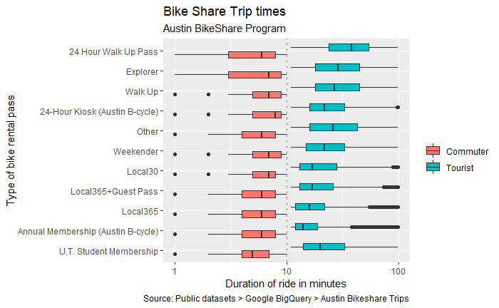

```r
austin_bikeshare_all %>%
  drop_na(subscriber_type) %>%
  filter(duration_minutes < 100) %>%
  mutate(travel_type = case_when(
    duration_minutes <= 10 ~ "Commuter",
    duration_minutes >  10 ~ "Tourist"
  )) %>%
  ggplot(aes(duration_minutes, fct_reorder(fct_lump(subscriber_type, prop = 0.01), duration_minutes))) +
  geom_boxplot(aes(fill = travel_type)) +
  geom_vline(xintercept = 10, linetype = "dashed", color = "grey60") +
  scale_x_log10() +
  labs(title = "Bike Share Trip times",
       subtitle = "Austin BikeShare Program",
       y = "Type of bike rental pass",
       x = "Duration of ride in minutes",
       caption = "Source: Public datasets > Google BigQuery > Austin Bikeshare Trips",
       fill = "")
```

```r
summary(austin_bikeshare_all)
```

```
    trip_id          subscriber_type       bikeid            start_time                  start_station_id
 Min.   :8.270e+06   Length:1264113     Length:1264113     Min.   :2013-12-21 09:12:00   Min.   :1001
 1st Qu.:1.597e+07   Class :character   Class :character   1st Qu.:2015-10-22 09:12:20   1st Qu.:2537
 Median :1.802e+07   Mode  :character   Mode  :character   Median :2017-06-25 13:56:04   Median :2567
 Mean   :2.774e+09                                         Mean   :2017-03-24 17:07:34   Mean   :2907
 3rd Qu.:9.900e+09                                         3rd Qu.:2018-06-05 12:58:28   3rd Qu.:3619
 Max.   :9.900e+09                                         Max.   :2020-06-30 22:04:11   Max.   :4062
                                                                                         NA's   :23154
 start_station_name end_station_id     end_station_name   duration_minutes
 Length:1264113     Length:1264113     Length:1264113     Min.   :    0.00
 Class :character   Class :character   Class :character   1st Qu.:    6.00
 Mode  :character   Mode  :character   Mode  :character   Median :   12.00
                                                          Mean   :   30.02
                                                          3rd Qu.:   27.00
                                                          Max.   :34238.00
```

## Example 2b: Austin BikeShare

List the top 5 percent of locations (stations) where bike-share trips begin and end.

Then, use `left_join()` to affect a database SQL join or table merge.

```r
left_tbl <- bikeshare_trips %>%
  count(start_station_name) %>%
  slice_max(order_by = n, prop = .05)
left_tbl
```

```
Complete
Billed: 31.46 MB
Downloading 9 rows in 1 pages.
```

| start_station_name | n |
| --- | --- |
| 21st & Speedway @PCL | 72799 |
| Riverside @ S. Lamar | 40635 |
| City Hall / Lavaca & 2nd | 36520 |
| 2nd & Congress | 35307 |
| Rainey St @ Cummings | 34758 |
| 5th & Bowie | 34283 |
| Davis at Rainey Street | 31529 |
| 4th & Congress | 31385 |
| Convention Center / 4th St. @ MetroRail | 31381 |

```r
right_tbl <- bikeshare_trips %>%
  count(end_station_name) %>%
  slice_max(order_by = n, prop = .05)
right_tbl
```

```
Complete
Billed: 31.46 MB
Downloading 9 rows in 1 pages.
```

| end_station_name | n |
| --- | --- |
| 21st & Speedway @PCL | 75055 |
| City Hall / Lavaca & 2nd | 41995 |
| Riverside @ S. Lamar | 39620 |
| 2nd & Congress | 38842 |
| 4th & Congress | 35240 |
| Convention Center / 4th St. @ MetroRail | 34010 |
| Rainey St @ Cummings | 33798 |
| 5th & Bowie | 32639 |
| Davis at Rainey Street | 31115 |

```r
left_join(left_tbl, right_tbl, by = c("start_station_name" = "end_station_name")) # %>% show_query()
```

```
Running job 'workshop-rfun-2021-spring.job_ZNPco1mUqrBRqhwwXaOoqItrCpYi.US' [-]  1s
Running job 'workshop-rfun-2021-spring.job_ZNPco1mUqrBRqhwwXaOoqItrCpYi.US' [\]  1s
Running job 'workshop-rfun-2021-spring.job_ZNPco1mUqrBRqhwwXaOoqItrCpYi.US' [|]  1s
Complete
Billed: 61.87 MB
Downloading 9 rows in 1 pages.
```

| start_station_name | n_x | n_y |
| --- | --- | --- |
| 21st & Speedway @PCL | 72799 | 75055 |
| Riverside @ S. Lamar | 40635 | 39620 |
| City Hall / Lavaca & 2nd | 36520 | 41995 |
| 2nd & Congress | 35307 | 38842 |
| Rainey St @ Cummings | 34758 | 33798 |
| 5th & Bowie | 34283 | 32639 |
| Davis at Rainey Street | 31529 | 31115 |
| 4th & Congress | 31385 | 35240 |
| Convention Center / 4th St. @ MetroRail | 31381 | 34010 |

## Example 3: NYC tree census

Inspired by [Edgar Ruiz’s dbplyr presentation](https://rstudio.com/resources/rstudioconf-2019/databases-using-r-the-latest/)

[DBplot](https://db.rstudio.com/dbplot/) leverages dplyr to process the calculations of a plot inside a database.

```r
con_ny_trees <- dbConnect(
  bigrquery::bigquery(),
  project = "bigquery-public-data",
  dataset = "new_york_trees",
  billing = "workshop-rfun-2021-spring"
)
con_ny_trees
```

```
<BigQueryConnection>
  Dataset: bigquery-public-data.new_york_trees
  Billing: workshop-rfun-2021-spring
```

```r
nytrees <- tbl(con_ny_trees, "tree_census_2015")
```

### Visualize

```r
library(dbplot)
library(leaflet)
```

```r
glimpse(nytrees)
```

```
Rows: ??
Columns: 41
Database: BigQueryConnection
$ tree_id    <int> 108086, 45875, 108093, 92792, 552482, 552487, 552491, 552483, 552492, 552488, 552485, 552486, 55248...
$ block_id   <int> 219845, 219919, 219845, 219850, 219811, 219811, 219811, 219811, 219811, 219811, 219811, 219811, 219...
$ created_at <date> 2015-08-01, 2015-07-01, 2015-08-01, 2015-07-25, 2016-03-31, 2016-03-31, 2016-03-31, 2016-03-31, 20...
$ tree_dbh   <int> 11, 4, 5, 2, 5, 5, 18, 20, 8, 20, 15, 5, 5, 11, 4, 9, 11, 16, 4, 4, 6, 7, 0, 5, 5, 4, 0, 7, 7, 6, 5...
$ stump_diam <int> 0, 0, 0, 0, 0, 0, 0, 0, 0, 0, 0, 0, 0, 0, 0, 0, 0, 0, 0, 0, 0, 0, 10, 0, 0, 0, 9, 0, 0, 0, 0, 0, 0,...
$ curb_loc   <chr> "OnCurb", "OnCurb", "OnCurb", "OnCurb", "OnCurb", "OnCurb", "OffsetFromCurb", "OffsetFromCurb", "On...
$ status     <chr> "Alive", "Alive", "Alive", "Alive", "Alive", "Alive", "Alive", "Alive", "Alive", "Alive", "Alive", ...
$ health     <chr> "Good", "Fair", "Good", "Good", "Good", "Good", "Good", "Good", "Good", "Good", "Good", "Good", "Go...
$ spc_latin  <chr> "Castanea mollissima", "Carpinus caroliniana", "Syringa reticulata", "Amelanchier", "Gleditsia tria...
$ spc_common <chr> "Chinese chestnut", "American hornbeam", "Japanese tree lilac", "serviceberry", "honeylocust", "hon...
$ steward    <chr> "1or2", "1or2", "1or2", "1or2", "1or2", "1or2", "1or2", "1or2", "1or2", "1or2", "1or2", "1or2", "1o...
$ guards     <chr> "Helpful", "None", "Helpful", "Helpful", "None", "None", "None", "None", "Helpful", "None", "None",...
```

[output cut: 29 more lines]

```r
nytrees %>%
  count(curb_loc)
```

```
Complete
Billed: 10.49 MB
Downloading 2 rows in 1 pages.
```

| curb_loc | n |
| --- | --- |
| OnCurb | 656896 |
| OffsetFromCurb | 26892 |

#### dbplot_raster()

```r
locations <- nytrees %>%
  filter(curb_loc == "OffsetFromCurb") %>%
  filter(health == "Good") %>%
  dbplot_raster(longitude, latitude, resolution = 30)
```

```
Running job 'workshop-rfun-2021-spring.job_ZvIIttqQjJQqKmyP6dd2qtD2Fbdl.US' [-]  1s
Running job 'workshop-rfun-2021-spring.job_ZvIIttqQjJQqKmyP6dd2qtD2Fbdl.US' [\]  1s
Running job 'workshop-rfun-2021-spring.job_ZvIIttqQjJQqKmyP6dd2qtD2Fbdl.US' [|]  1s
Complete
Billed: 20.97 MB
Downloading 364 rows in 1 pages.
```

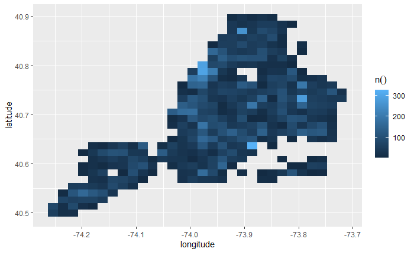

```r
  # db_compute_raster(longitude, latitude, resolution = 30)
locations
```

#### db_compute_raster()

```r
nytrees %>%
  filter(curb_loc == "OffsetFromCurb") %>%
  filter(health == "Good") %>%
  count()
```

```
Complete
Billed: 10.49 MB
Downloading 1 rows in 1 pages.
```

| n |
| --- |
| 20877 |

```r
locations_tbl <- nytrees %>%
  filter(curb_loc == "OffsetFromCurb") %>%
  filter(health == "Good") %>%
  db_compute_raster(longitude, latitude, resolution = 30)
```

```
Complete
Billed: 0 B
Downloading 364 rows in 1 pages.
```

```r
locations_tbl
```

| longitude | latitude | n() |
| --- | --- | --- |
| -73.99572 | 40.69122 | 115 |
| -73.99572 | 40.67748 | 26 |
| -74.01411 | 40.69122 | 27 |
| -73.94053 | 40.58131 | 8 |
| -73.94053 | 40.59505 | 152 |
| -73.95893 | 40.58131 | 82 |
| -73.95893 | 40.56757 | 32 |
| -73.94053 | 40.56757 | 21 |
| -73.95893 | 40.59505 | 63 |
| -73.97732 | 40.58131 | 168 |

[output cut: 354 more lines]

#### Tidy evaluation functions

Tidy eval function [by Ruiz (timestamp 13:47)](https://rstudio.com/resources/rstudioconf-2019/databases-using-r-the-latest/)

```r
size <- function(df, field) {
  field <- enquo(field)
  df %>%
    arrange(!! field) %>%
    mutate(diff = !! field - lag(!! field)) %>%
    filter(diff > 0) %>%
    summarise(min(diff)) %>%
    pull()
}
```

```r
lon_size <- locations_tbl %>%
  size(longitude)

lon_size
```

```
[1] 0.01839551
```

```r
lat_size <- locations_tbl %>%
  size(latitude)

lat_size
```

```
[1] 0.01373925
```

```r
sq <- locations_tbl %>%
  mutate(lon1 = longitude,
         lon2 = longitude + lon_size,
         lat1 = latitude,
         lat2 = latitude + lat_size,
         of_max = `n()` / max(`n()`)
  )
```

#### Leaflet map

```r
leaflet() %>%
  addTiles() %>%
  addRectangles(
    sq$lon1, sq$lat1, sq$lon2, sq$lat2
  )
```

[interactive chart not shown]

```r
fancy <- leaflet() %>%
  addTiles() %>%
  addProviderTiles(providers$CartoDB.Positron) %>%
  addRectangles(
    sq$lon1, sq$lat1, sq$lon2, sq$lat2,
    fillOpacity = sq$of_max,
    fillColor = "forestgreen",
    stroke = FALSE,
    popup = glue::glue('Trees {sq$`n()`}')
  )

fancy
```

[interactive chart not shown]

```r
library(mapview)

mapshot(fancy, file = "images/tree_cover.png")
```

## Resources

- [Databases using R](https://db.rstudio.com/)
- [library(DBI)](https://dbi.r-dbi.org/reference/)
- [library(bigrquery)](https://bigrquery.r-dbi.org/)
- [library(dbplyr)](https://dbplyr.tidyverse.org/)
- [RStudio Conf 2019, 15 min. Recording](https://rstudio.com/resources/rstudioconf-2019/databases-using-r-the-latest/)